# MEML_HW_01_Soln

**Machine Learning for Mechanical Engineering**  
**Homework 01: Solution**  
**Due Tuesday, 03/19/2019, 9:30 AM**

By Prof. Seungchul Lee  
http://iai.postech.ac.kr/  
Industrial AI Lab at POSTECH

- For your handwritten solution, hand in your hardcopy to TA.
- For your code, email your .ipynb file to `iai.postech@gmail.com`. Only .ipynb file will be graded.
- When you send an e-mail, write down [Machine Learning Homework] on the title
- And please write your NAME on your .ipynb files. ex) 이남정_20192319_HW1.ipynb
- Do not submit a printed version of your code. It will not be graded.

# Problem 1

Prove that any projection matrix $P$ for an orthogonal projection in $\mathbb{R}^n$ satisfies the two properties:

(a) $P^2 = P$

(b) $P$ is symmetric

### Solution

(a) By definition, for any $x \in \mathbb{R}^n$

$$\begin{align*} P\left(Px\right) &= Px\\ P^2x &= Px\\ \left(P^2 - P\right)x &= 0 \end{align*}$$

(b)

[figure not shown]

By definition, for any $x, y \in \mathbb{R}^n$

$$\left(Px - Py\right) \perp \left(y-Py\right)$$

Consequently,

$$0 = \left(Px - Py\right)^T\left(y-Py\right) = \left(x-y\right)^Tp^T\left(I-P\right)y = \left(x-y\right)^T\left(P^T-P^TP\right)y=0$$

for any $x, y \in \mathbb{R}^n$. This shows that $P^T = P^TP$. Then, $P = \left(P^T\right)^T = \left(P^TP\right)^T = P^TP = P^T$

# Problem 2

Show that the hyperplane $g(X) = \omega^TX + b = 0$ is perpendicular to $\omega$.

### Solution

If $X_1$ and $X_2$ are any points on the hyperplane, then the followings are satisfied:

$$\begin{align*} g(X_1) = \omega^TX_1 + b = 0\\ g(X_2) = \omega^TX_2 + b = 0 \end{align*} $$

We can show that

$$g(X_1) - g(X_2) = \omega^TX_1 - \omega^TX_2 = \omega^T(X_1 - X_2) = 0 \implies \omega \perp (X_1 - X_2)$$

# Problem 3

Let $x$ be a block vector with two vector elements, $x = \begin{bmatrix}a\\b\end{bmatrix}$ where $a$ and $b$ are vectors of size $n$ and $m$, respectively. Show that

$$\lVert x \rVert = \left(\lVert a \rVert^2 + \lVert b \rVert^2 \right)^{\frac{1}{2}} = \left\lVert \begin{bmatrix} \lVert a \rVert \\ \lVert b \rVert \end{bmatrix} \right\rVert$$

(Note that the norm on the right-hand side is of a 2-vector)

### Solution

$$\begin{align*} \lVert x \rVert^2 &= \lVert a \rVert^2 + \lVert b \rVert^2\\ \\ \lVert a \rVert^2 + \lVert b \rVert^2 &= \left \lVert \begin{bmatrix} \lVert a \rVert \\ \lVert b \rVert \end{bmatrix} \right \rVert^2 \end{align*}$$

# Problem 4

Represent each of the following three functions $f: \mathbb{R}^2 \rightarrow \mathbb{R}^2$ as a matrix-vector product $f(x) = Ax$

(a) $f(x)$ is obtained by reflecting $x$ about the $x_1$ axis

(b) $f(x)$ is $x$ reflected about the $x_1$ axis, followed by a counter clockwise rotation of 30 degrees.

(c) $f(x)$ is $x$ rotated counterclockwise over 30 degrees, followed by a reflection about the $x_1$ axis

### Solution

(a)

$$f(x) = \begin{bmatrix} 1 & 0 \\ 0 & -1 \end{bmatrix}x$$

(b)

$$\begin{align*} R(\theta) &: \text{ rotation matrix }\\ f(x) &= R\left(\frac{\pi}{6}\right)\begin{bmatrix}1&0\\0&-1\end{bmatrix} \end{align*}$$

(c)

$$f(x) = \begin{bmatrix} 1 & 0 \\ 0 & -1 \end{bmatrix}R\left(\frac{\pi}{6}\right)$$

# Problem 5

Fibonacci sequence is defined as the follwing:

$$F_{k+2} = F_{k+1} + F_{k} \qquad \text{with} \;F_0 = 0, \;F_1 = 1$$

It is known that the ratio of $F_{k+1}$ to $F_{k}$ is close to 'golden mean'. That is,

$$\lim_{k \to \infty} \frac{F_{k+1}}{F_{k}} = \frac{\left(1 + \sqrt{5}\right)}{2}$$

Show the above equation using eigenvectors and eigenvalues.

### Solution

$ F_{k+2} = F_{k+1}+F_k$ is the second oreder linear system

$$ \begin{bmatrix} F_{k+2} \\ F_{k+1} \end{bmatrix} = \begin{bmatrix} 1 & 1 \\ 1 & 0 \end{bmatrix} \begin{bmatrix} F_{k+1} \\ F_{k} \end{bmatrix} $$

$ \text{Eigen Anlaysis} $

$$ \text{det}(A-\lambda I) =0 $$$$ \lambda_1 ,\ \lambda_2 = \frac{1\pm \sqrt5}{2} $$

$X_1)$ $$ \begin{align} & \begin{bmatrix} 1-\frac{1 + \sqrt5}{2} & 1 \\ 1 & -\frac{1 + \sqrt5}{2} \end{bmatrix} \begin{bmatrix} \\[0.01em] X_1 \\ \\[0.01em] \end{bmatrix} \\ \\ \implies & \begin{bmatrix} \frac{1 - \sqrt5}{2} & 1 \\ 1 & \frac{-1 - \sqrt5}{2} \end{bmatrix} \begin{bmatrix} \frac{1 + \sqrt5}{2} \\[0.6em] 1 \end{bmatrix} = 0 \\ \end{align} $$

$\text{So,}$

$$ X_1 = \begin{bmatrix} \frac{1 + \sqrt5}{2} \\ 1 \end{bmatrix} $$

$X_2$) Replacing $\sqrt5 \rightarrow -\sqrt5 $ to the previous result gives

$$ X_2 = \begin{bmatrix} \frac{1 - \sqrt5}{2} \\ 1 \end{bmatrix} \\ \\ $$

$$ \begin{align} \text{So,} \quad \begin{bmatrix} F_{n+1} \\ F_{n} \end{bmatrix} & = \begin{bmatrix} 1 & 1 \\ 1 & 0 \end{bmatrix}^n \begin{bmatrix} F_1 \\ F_0 \end{bmatrix} \\ \\ & = C_1\left(\frac{1 + \sqrt5}{2}\right)^n x_1 + C_2 \left(\frac{1 - \sqrt5}{2}\right)^n x_2 \\ \\ \text{Then,} \quad \lim\limits_{n \to \infty} \frac{F_{n+1}}{F_{n}} & = \lim\limits_{n \to \infty} \frac{C_1\left(\frac{1 + \sqrt5}{2}\right)^{n+1} }{C_1\left(\frac{1 + \sqrt5}{2}\right)^n } \\ \\ & = \frac{1 + \sqrt5}{2} \\ \\ \end{align} $$

$$ \left(* \lim\limits_{n \to \infty} \left(\frac{1 - \sqrt5}{2}\right)^n = 0 \quad \text{since, } \left\lvert\frac{1 - \sqrt5}{2}\right\rvert < 1 \right) $$

# Problem 6

(a) Find the solution using the derivatives of the following objective function:

$$\min_{x} \,\,\, (2x_1 - 1)^2 + (-x_1 + x_2)^2 + (2x_2 +1)^2$$

(b) Formulate the above corresponding least-squares problem (*i.e.*, find one of possible $A$ and $b$), and solve it using cvxpy.

$$\min_{x} \, \lVert Ax - b\rVert_2 ^2$$

(c) How many suboptimal points exist? Why?

### Solution

(a)

Let

$$ \begin{align*} f &= (2x_1 - 1)^2 + (-x_1 + x_2)^2 + (2x_2 +1)^2 \\ \\ \frac{\partial f}{\partial x_1} &= 2(2x_1 - 1)2 + (-x_1 + x_2)(-1) = 10x_1 - 2x_2 - 4 = 0 \\ \frac{\partial f}{\partial x_2} &= 2(-x_1 + x_2) + 2(2x_2 + 1)2 = -2x_1 + 10x_2 + 4 = 0 \\ \end{align*} $$

Matrix form

$$ \begin{bmatrix} 10 & -2 \\ -2 & 10 \end{bmatrix} \begin{bmatrix} x_1 \\ x_2 \end{bmatrix} + \begin{bmatrix} -4 \\ 4 \end{bmatrix} = 0 $$

So, $$ \begin{bmatrix} x_1 \\ x_2 \end{bmatrix} = \begin{bmatrix} 10 & -2 \\ -2 & -10 \end{bmatrix}^{-1} \begin{bmatrix} -4 \\ 4 \end{bmatrix} = \frac{1}{96}\begin{bmatrix} 10 & 2 \\ 2 & 10 \end{bmatrix} \begin{bmatrix} -4 \\ 4 \end{bmatrix} =\frac{1}{3}\begin{bmatrix} 1 \\ -1 \end{bmatrix} $$

Thus $$ x_1 = \frac{1}{3} \quad \text{and}\quad x_2 = -\frac{1}{3} $$

(b)

```python
import numpy as np
import cvxpy as cvx

x = cvx.Variable(2, 1)
A = np.array([[2, 0], [-1, 1], [0, 2]])
b = np.array([[1], [0], [-1]])
objective = cvx.Minimize(cvx.norm(A*x - b, 2))
prob = cvx.Problem(objective)
result = prob.solve()

print(x.value)
print(result**2)
```

```
[[ 0.33333333]
 [-0.33333333]]
0.6666666662110364
```

(c)

Zero (or one global optimum). This function has no subpotimal point since it is convex. We need to probe the function is a convex function

$$ \frac{\partial f}{\partial x_1} =2(2x_1 - 1)2 + (-x_1 + x_2)(-1) = \ 10x_1 - 2x_2 - 4 = 0 $$$$ \frac{\partial f}{\partial x_2} =2(-x_1 + x_2) + 2(2x_2 + 1)2 = \ -2x_1 + 10x_2 + 4 = 0 $$

$$ \frac{\partial^2 f}{\partial x_1^2} =2\cdot2\cdot2 + 2 = 10 \qquad \frac{\partial^2 f}{\partial x_1\partial x_2} = -2 $$

$$ \frac{\partial^2 f}{\partial x_2^2} =2 + 2\cdot2\cdot2 = 10 \qquad \frac{\partial^2 f}{\partial x_1\partial x_2} = -2 $$

$f(x) = \mathbb{R}^2\to\mathbb{R}$ & it is twice differentiable over an open domain.  
Then,

$$ \frac{\partial^2 f}{\partial x^2}= \begin{bmatrix}\frac{\partial^2 f}{\partial x_1^2}& \frac{\partial^2 f}{\partial x_1\partial x_2} \\ \frac{\partial^2 f}{\partial x_1\partial x_2}& \frac{\partial^2 f}{\partial x_2^2} \end{bmatrix}= \begin{bmatrix}10&-2 \\ -2&10 \end{bmatrix}\ $$

Use Hessian determinant

$$\det \left(\frac{\partial^2 f}{\partial x^2} \right)= 100 - 4 = 96 \geq 0 \quad \text{for all }x \in \text{domain}(f(x))$$

Thus, $f(x)$ is a convex function

# Problem 7

In this homework, we want to demonstrate an image panorama as an example of linear regression. A panorama is any wide-angle view or representation of a physical space.

[figure not shown]

### 1) Load Images

```python
import numpy as np
import matplotlib.pyplot as plt
import cv2
```

```python
imag1 = cv2.imread('./image_files/panorama_postech_left.jpg')
imag1 = cv2.cvtColor(imag1, cv2.COLOR_BGR2RGB)
imag2 = cv2.imread('./image_files/panorama_postech_front.jpg')
imag2 = cv2.cvtColor(imag2, cv2.COLOR_BGR2RGB)
imag3 = cv2.imread('./image_files/panorama_postech_right.jpg')
imag3 = cv2.cvtColor(imag3, cv2.COLOR_BGR2RGB)
```

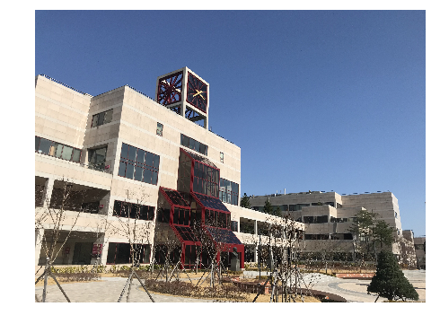

```python
plt.figure(figsize=(10, 6))
plt.imshow(imag1)
plt.axis('off')
plt.show()
```

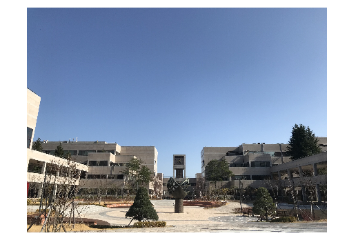

```python
plt.figure(figsize=(10, 6))
plt.imshow(imag2)
plt.axis('off')
plt.show()
```

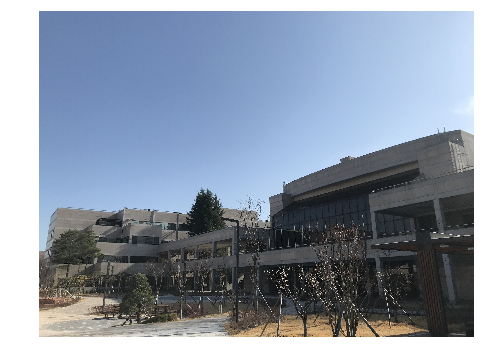

```python
plt.figure(figsize=(10, 6))
plt.imshow(imag3)
plt.axis('off')
plt.show()
```

### 2) Visualization of key points

- Suppose these matching points are given.
  - We have manually found the matching points for you, although there is a technique to do this automatically.
- pos1 and pos2 are matching points between img01 and img02
- pos3 and pos4 are matching points between img02 and img03

```python
pos1 = np.array([[2121, 2117, 2749, 3095, 3032, 3375, 3677, 3876],
                 [1431, 2034, 2033, 1885, 2017, 2037, 1885, 2279]], dtype=np.int64)## Find key points between two images
pos2 = np.array([[188, 58, 828, 1203, 1121, 1437, 1717, 1817],
                 [1217, 1909, 1952, 1827, 1952, 1991, 1870, 2226]], dtype=np.int64)
pos3 = np.array([[2338, 2379, 2658, 2899, 2977, 3272, 2716, 2786],
                 [1948, 1874, 2000, 1837, 1964, 1966, 2143, 2317]], dtype=np.int64)
pos4 = np.array([[109, 178, 497, 795, 851, 1144, 534, 580],
                 [1907, 1828, 1988, 1834, 1971, 1993, 2145, 2333]], dtype=np.int64)
```

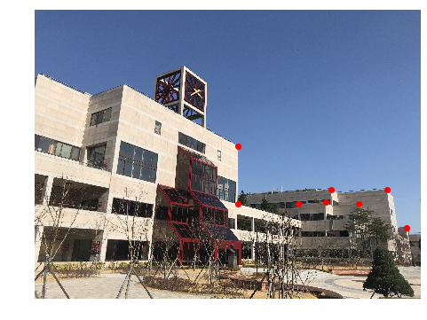

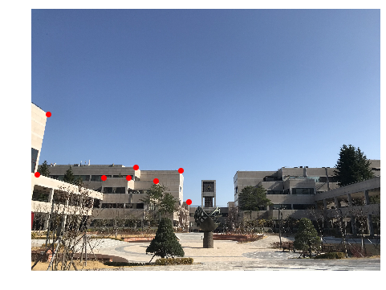

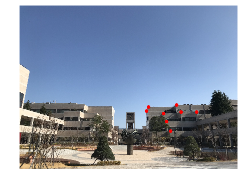

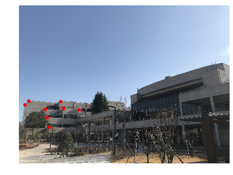

```python
plt.figure(figsize=(10, 6))
plt.imshow(imag1)
plt.plot(pos1[0,:], pos1[1,:], 'ro', 'linewidth', 1)
plt.axis('off')
plt.show()

plt.figure(figsize=(10, 6))
plt.imshow(imag2)
plt.plot(pos2[0,:], pos2[1,:], 'ro', 'linewidth', 1)
plt.axis('off')
plt.show()

plt.figure(figsize=(10, 6))
plt.imshow(imag2)
plt.plot(pos3[0,:], pos3[1,:], 'ro', 'linewidth', 1)
plt.axis('off')
plt.show()

plt.figure(figsize=(10, 6))
plt.imshow(imag3)
plt.plot(pos4[0,:], pos4[1,:], 'ro', 'linewidth', 1)
plt.axis('off')
plt.show()
```

### 3) Perspective homography for image 1 and image 2

```python
Phi01 = []
newpos01 = []
for i in range(8):
    temp1 = [[pos1[0,i], pos1[1,i], 1, 0, 0, 0, -pos2[0,i]*pos1[0,i], -pos2[0,i]*pos1[1,i]],
            [0, 0, 0, pos1[0,i], pos1[1,i], 1, -pos2[1,i]*pos1[0,i], -pos2[1,i]*pos1[1,i]]]
    temp2 = [[pos2[0,i]], [pos2[1,i]]]
    Phi01.append(temp1)
    newpos01.append(temp2)

Phi01 = np.concatenate(Phi01, axis=0)
newpos01 = np.concatenate(newpos01, axis=0).reshape(-1, 1)
Phi01 = np.asmatrix(Phi01)
newpos01 = np.asarray(newpos01)

perspective_theta = (Phi01.T*Phi01).I*Phi01.T*newpos01
perspective_theta = np.vstack([perspective_theta, [1]])
perspective_theta = perspective_theta.reshape(3, 3)
```

### 4) Perspective homography for image 2 and image 3

```python
# Perspective homography for image  and image 2

Phi03 = []
newpos03 = []
for i in range(8):
    temp1 = [[pos4[0,i], pos4[1,i], 1, 0, 0, 0, -pos3[0,i]*pos4[0,i], -pos3[0,i]*pos4[1,i]],
            [0, 0, 0, pos4[0,i], pos4[1,i], 1, -pos3[1,i]*pos4[0,i], -pos3[1,i]*pos4[1,i]]]
    temp2 = [[pos3[0,i]], [pos3[1,i]]]
    Phi03.append(temp1)
    newpos03.append(temp2)

Phi03 = np.concatenate(Phi03, axis=0)
newpos03 = np.concatenate(newpos03, axis=0).reshape(-1, 1)
Phi03 = np.asmatrix(Phi03)
newpos03 = np.asarray(newpos03)

perspective_theta3 = (Phi03.T*Phi03).I*Phi03.T*newpos03
perspective_theta3 = np.vstack([perspective_theta3, [1]])
perspective_theta3 = perspective_theta3.reshape(3, 3)
```

```python
translation = np.matrix([[1, 0, 6000],
                         [0, 1, 2500],
                         [0, 0, 1]])
```

### 5) Image warping

- Again, do not worry about the image warping (outside lecture's scope)

```python
warpedImage = cv2.warpPerspective(imag1, translation*perspective_theta, (18000, 6500))
warpedImage3 = cv2.warpPerspective(imag3, translation*perspective_theta3, (18000, 6500))
```

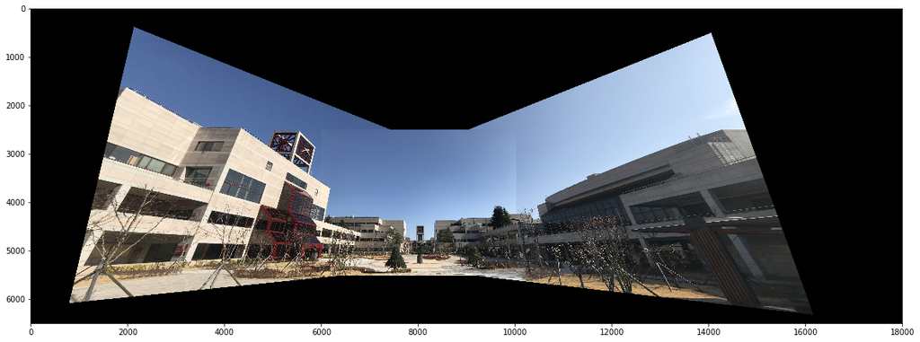

```python
screen = warpedImage.copy()
screen[screen==0] = warpedImage3[screen==0]
screen[2500:3024+2500,6000:4032+6000] = imag2


plt.figure(figsize=(20, 12))
plt.imshow(screen)
plt.show()
```